# HW06_ploter

```r
library(tidyverse)
library(tidymodels)
library(GGally)
library(discrim)
```

## Prepare data

Use the command set.seed(your_study_book_nuber) to fix randomness (your_study_book_number should be equal to the numerical part of your study book number).

```r
set.seed(39692)
```

Use the data from HW6_Loan.csv. The aim is to predict probability of default of new applications. Note that again Education,Gender and OccupationArea are actually nominal variables.

```r
df = read_delim("HW6_Loan.csv", delim = ",")
df = recipe(default ~ ., data = df) |> step_string2factor(default) |> prep() |> bake(new_data=NULL)
```

```r
head(df)
```

| Gender | LoanDuration | Age | Amount | DebtToIncome | Education | ExistingLiabilities | OccupationArea | default |
| --- | --- | --- | --- | --- | --- | --- | --- | --- |
| 0 | 12 | 47 | 1000 | 29.04 | 3 | 2 | 1 | No |
| 0 | 36 | 60 | 4000 | 48.51 | 4 | 8 | 11 | Yes |
| 0 | 48 | 27 | 1595 | 11.49 | 4 | 2 | 19 | No |
| 1 | 36 | 50 | 1400 | 29.04 | 4 | 4 | 16 | No |
| 0 | 36 | 37 | 1000 | 5.97 | 2 | 1 | 1 | Yes |
| 0 | 48 | 64 | 3720 | 62.96 | 4 | 4 | 7 | No |

```r
table(df$default)
```

```
   No   Yes
22281 10117
```

```r
table(df$Education)
```

```
   -1     0     1     2     3     4     5
   23     4  1959  1907  5946 13169  9390
```

```r
str(df)
```

```
tibble [32,398 × 9] (S3: tbl_df/tbl/data.frame)
 $ Gender             : num [1:32398] 0 0 0 1 0 0 0 0 0 1 ...
 $ LoanDuration       : num [1:32398] 12 36 48 36 36 48 24 36 12 48 ...
 $ Age                : num [1:32398] 47 60 27 50 37 64 22 21 40 24 ...
 $ Amount             : num [1:32398] 1000 4000 1595 1400 1000 ...
 $ DebtToIncome       : num [1:32398] 29.04 48.51 11.49 29.04 5.97 ...
 $ Education          : num [1:32398] 3 4 4 4 2 4 2 3 3 4 ...
 $ ExistingLiabilities: num [1:32398] 2 8 2 4 1 4 1 1 5 2 ...
 $ OccupationArea     : num [1:32398] 1 11 19 16 1 7 6 6 1 12 ...
 $ default            : Factor w/ 2 levels "No","Yes": 1 2 1 1 2 1 1 1 1 1 ...
```

```r
levels(df$default)
```

```
[1] "No"  "Yes"
```

Split the data into training and model comparison parts (equal size)

```r
default_split = initial_split(df, prop = 0.5, strata = default)
train_df = training(default_split)
test_df = testing(default_split)
```

```r
df_recipe = recipe(default ~ ., data = train_df) |>
  step_dummy(all_nominal_predictors()) |>
  step_normalize(all_numeric_predictors())
```

## Logistic regression model

Fit the best logistic regression model you can find in reasonable amount of time to the training data and describe what you tried and why the final model is the best of the ones you compared.

```r
df_recipe = recipe(default ~ ., data = train_df) |>
  step_dummy(all_nominal_predictors()) |>
  step_normalize(all_numeric_predictors())

log_model = logistic_reg() |>
  set_engine("glm") |>
  set_mode("classification")

log_workflow = workflow() |>
  add_model(log_model) |>
  add_recipe(df_recipe)

log_fit = fit(log_workflow, data = train_df)
```

```r
tidy(log_fit)
```

| term | estimate | std.error | statistic | p.value |
| --- | --- | --- | --- | --- |
| (Intercept) | -0.81361043 | 0.01734360 | -46.9112644 | 0.000000e+00 |
| Gender | 0.03109787 | 0.01744708 | 1.7824111 | 7.468221e-02 |
| LoanDuration | 0.28789226 | 0.01888524 | 15.2442958 | 1.796596e-52 |
| Age | -0.01697523 | 0.01762020 | -0.9633961 | 3.353488e-01 |
| Amount | 0.00672662 | 0.01797829 | 0.3741523 | 7.082910e-01 |
| DebtToIncome | 0.14134872 | 0.02272863 | 6.2189729 | 5.004196e-10 |
| Education | -0.13570955 | 0.01711836 | -7.9277212 | 2.232036e-15 |
| ExistingLiabilities | 0.03939633 | 0.01874625 | 2.1015581 | 3.559201e-02 |
| OccupationArea | 0.06542715 | 0.02140799 | 3.0562023 | 2.241600e-03 |

We consider predictors associated with small p-value.

```r
df_recipe = recipe(default ~ Gender+LoanDuration+DebtToIncome+Education+Education+ExistingLiabilities+OccupationArea, data = train_df) |>
  step_dummy(all_nominal_predictors()) |>
  step_normalize(all_numeric_predictors())

log_workflow = workflow() |>
  add_model(log_model) |>
  add_recipe(df_recipe)

log_fit = fit(log_workflow, data = train_df)
```

Produce a box plot, which shows predicted probabilities for defaulting loans and for non-defaulting loans on model comparison set.

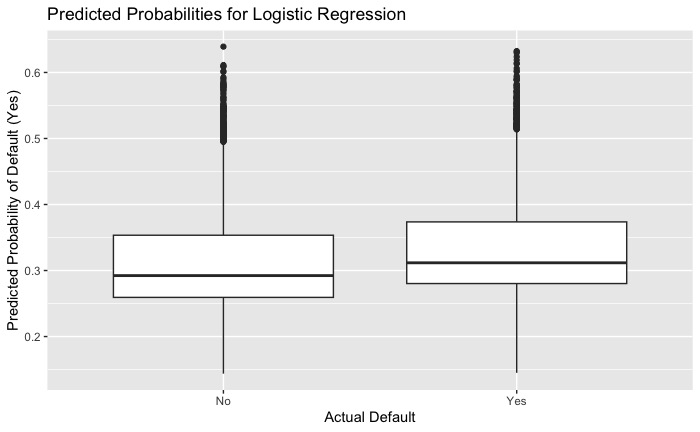

```r
log_preds = predict(log_fit, test_df, type = "prob") |>
  bind_cols(test_df)

ggplot(log_preds, aes(x = default, y = .pred_Yes)) +
  geom_boxplot() +
  labs(title = "Predicted Probabilities for Logistic Regression",
       x = "Actual Default", y = "Predicted Probability of Default (Yes)")
```

Produce confusion matrix when using the model for classification the observations in the model comparison set with cutoff corresponding to probability of default (default=Yes) equal to 0.3. Can defaulting loans be accurately predicted?

```r
augment(log_fit,new_data=test_df)|>mutate(.pred_class=factor(if_else(.pred_Yes>0.3,"Yes","No"),levels=c("No", "Yes")))|>conf_mat(default,.pred_class)
```

```
          Truth
Prediction   No  Yes
       No  6139 2123
       Yes 5002 2936
```

## LDA model

Fit LDA model to the training data leaving out OccupationArea and using all other variables as numeric variables

```r
lda_model = discrim_linear() |>
  set_engine("MASS") |>
  set_mode("classification")

lda_recipe = recipe(default ~ ., data = train_df) |>
  step_rm(OccupationArea) |>
  step_normalize(all_numeric_predictors())

lda_workflow = workflow() |>
  add_model(lda_model) |>
  add_recipe(lda_recipe)

lda_fit = fit(lda_workflow, data = train_df)
```

produce box plot of probabilities of default for defaulting loans and non-defaulting loans in the case of model comparison set(predicted probabilities for classes can be obtained by predict(model)$posterior)

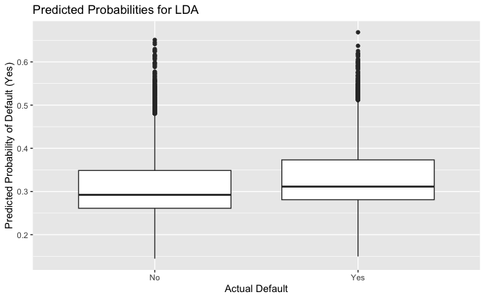

```r
lda_preds = predict(lda_fit, test_df, type = "prob") |>
  bind_cols(test_df)

ggplot(lda_preds, aes(x = default, y = .pred_Yes)) +
  geom_boxplot() +
  labs(title = "Predicted Probabilities for LDA",
       x = "Actual Default", y = "Predicted Probability of Default (Yes)")
```

```r
augment(lda_fit,new_data=test_df)|>mutate(.pred_class=factor(if_else(.pred_Yes>0.3,"Yes","No"),levels=c("No", "Yes")))|>conf_mat(default,.pred_class)
```

```
          Truth
Prediction   No  Yes
       No  6110 2143
       Yes 5031 2916
```

## QDA model

Fit QDA model to the training data leaving out OccupationArea and using all other variables as numeric variables

```r
qda_model = discrim_quad() |>
  set_engine("MASS") |>
  set_mode("classification")

qda_workflow = workflow() |>
  add_model(qda_model) |>
  add_recipe(lda_recipe) # Using the same recipe

qda_fit = fit(qda_workflow, data = train_df)
```

produce box plot of probabilities of default for defaulting loans and non-defaulting loans in the case of model comparison set(predicted probabilities for classes can be obtained by predict(model)$posterior)

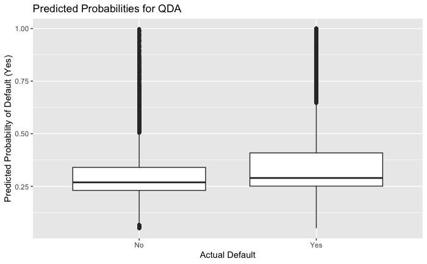

```r
qda_preds = predict(qda_fit, test_df, type = "prob") |>
  bind_cols(test_df)

ggplot(qda_preds, aes(x = default, y = .pred_Yes)) +
  geom_boxplot() +
  labs(title = "Predicted Probabilities for QDA",
       x = "Actual Default", y = "Predicted Probability of Default (Yes)")
```

```r
augment(qda_fit,new_data=test_df)|>mutate(.pred_class=factor(if_else(.pred_Yes>0.3,"Yes","No"),levels=c("No", "Yes")))|>conf_mat(default,.pred_class)
```

```
          Truth
Prediction   No  Yes
       No  7406 2750
       Yes 3735 2309
```

## Summary

If detecting actual defaults is the priority which might be the case in bank, then logistic regression or LDA models seems more appropriate due to their higher true positive rates and lower false negative rates.